# AN 588 Week 3

Erin Anderson

2023-10-05

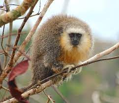

Titi monkies!

## Challenges

I learned how to best import an image into my Rmarkdown from my peers as I was struggling with adding images that were easy to access via R and view on the final knit of my html file.

The major difference in my code that I didn’t see in my peers code was the inclusion of upper.tri(TRUE) when solving the first homework problem. I used this method as a way to call the greater than or equal to parameter. My peers used 1 - ppois(q = 8, lqmbda = 15) to account for this variable which I thought was a unique and creative way of solving the same problem.

I thought that overall this homework was relatively straight forward. The coding issues I struggled with most I was able to fix either via reviewing the modules or from the peer feedback I recieved on my initial homework code.

I thought the comments my peers left me were very helpful, kind, and overall improved my understanding of the assignment. I enjoyed looking through my peer’s code and seeing how they chose to tackle the same problem, and felt like I learned a lot through their feedback and problem solving processes.

## What is the probability she will hear more than 8 calls during any given session?

```r
eight_calls <- ppois(q = 8, lambda = 15, upper.tri(TRUE))
eight_calls
```

```
## [1] 0.9625535
```

## Probability of no calls

```r
no_calls <- dpois(x = 0, lambda =15)
no_calls
```

```
## [1] 3.059023e-07
```

## Probability of exactly 3 calls

```r
three_calls <- dpois(x = 3, lambda =15)
three_calls
```

```
## [1] 0.0001720701
```

## Plot the relevant Poisson mass function over the values in range 0 ≤ x ≤ 30.

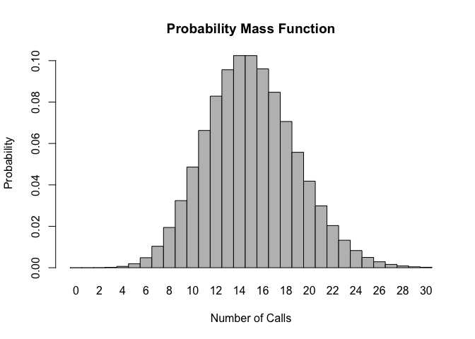

```r
x <- 0:30
l = 15
probset <- dpois(x = x, lambda = l)
barplot(probset, names.arg = x, space = 0, xlab = "Number of Calls", ylab = "Probability", main = "Probability Mass Function")
```

## Simulate 104 results from this distribution (i.e., 2 years of Saturday monitoring sessions)

```r
two_years <- rpois(104, lambda =15)
two_years
```

```
##   [1] 21 21  9 13 14 12 33 14  8 15 19 17 19 14 11 12 17 18 18 19 13 14 16 11 14
##  [26] 24 11 13 22 17 13 16 13 13 18 13 16 20 20 11 17  9 21 18 17 11 18 15 19 24
##  [51] 13 14 11 20 21 18 17 20 17 11 17 14 16 15 20 16 15 15 13 15 19  9 18 15 16
##  [76] 27 12 18  9 11 12 17 13 21 17 13 13 23 10 15 12 15 13 19 19 15 17 12 13 10
## [101] 11 19 17 12
```

## Plot the simulated results using hist() and use xlim() to set the horizontal limits to be from 0 to 30

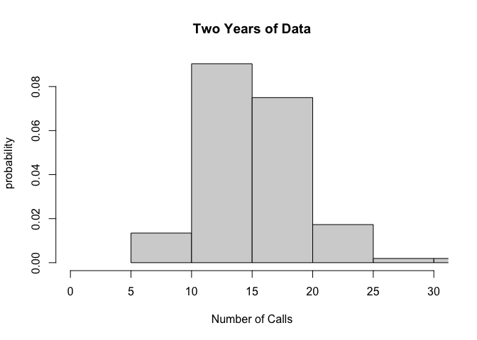

```r
hist(two_years, probability = TRUE, main = "Two Years of Data",
    xlab = "Number of Calls", ylab = "probability", xlim = c(0,30))
```